# Part_II_slide_deck_template

## Investigation Overview

In this presentation, my primary focus is primarily on the factors that predicts how long a rider will ride a bike (duration) .

## Dataset Overview

> Ford GoBike System Data exploration describes the exploration of data of riders obtained in a bike-sharing system covering the greater San Francisco Bay area. In this dataset, I will draw useful insight on predictors of how long a rider can ride.

```python
# import all packages and set plots to be embedded inline
import numpy as np
import pandas as pd
import matplotlib.pyplot as plt
import seaborn as sb

%matplotlib inline

# suppress warnings from final output
import warnings
warnings.simplefilter("ignore")
```

```python
# Loading the csv file to a dataframe
bike_clean = pd.read_csv('bike_clean.csv')

# Drop this unnamed column index using the code below.
bike_clean.drop('Unnamed: 0',axis=1, inplace=True)
```

```python
# convert user_type, gender, user_type and weekday into ordered categorical types
ordinal_var_dict = {'user_type': ['Customer', 'Subscriber'],
                    'gender': ['Male', 'Female', 'Other'],
                    'weekday': ['Mon','Tue','Wed','Thu','Fri','Sat','Sun']}

for var in ordinal_var_dict:
    ordered_var = pd.api.types.CategoricalDtype(ordered = True,
                                                categories = ordinal_var_dict[var])
    bike_clean[var] = bike_clean[var].astype(ordered_var)
```

## Visualization 1: Distribution of biker's duration for riding bike

- The distribution of the main dataset which is duration showed that the longest duration the bikers rode for is between 8-12mins.

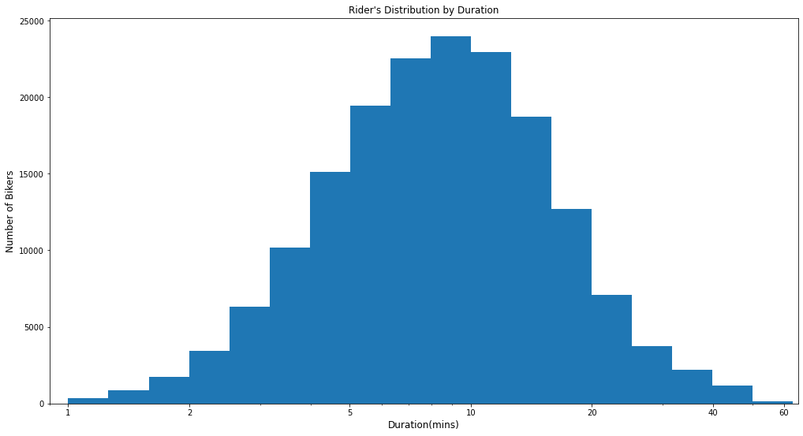

```python
plt.figure(figsize=[17,9])

# Get the ticks for bins between [0 - maximum weight]
bins = 10 ** np.arange(0, 2+0.1, 0.1)

# Generate the x-ticks you want to apply
ticks = [1, 2, 5, 10, 20, 40, 60]
# Convert ticks into string values, to be displayed long the x-axis
labels = ['{}'.format(v) for v in ticks]

# Plot the histogram
plt.hist(data= bike_clean, x= 'duration_min', bins=bins);

# The argument in the xscale() represents the axis scale type to apply.
# The possible values are: {"linear", "log", "symlog", "logit", ...}
plt.xscale('log')
plt.xlim(0.9, 65)

# Apply x-ticks
plt.xticks(ticks, labels);

plt.xlabel('Duration(mins)', fontsize = 12);
plt.ylabel('Number of Bikers',fontsize = 12);
plt.title("Rider's Distribution by Duration");
```

## Visualization 2: Distribution by distance covered by bikers

- The distance covered by most bikers in the biking sharing system is between 0.8km and 1.2km. Most bikers prefers to ride for a short distance than a long distance.

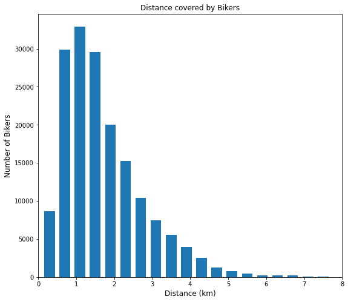

```python
plt.figure(figsize = [9,8])
bins = np.arange(0.1, bike_clean['distance_km'].max()+1, 0.4)
plt.hist(data = bike_clean, x= 'distance_km', bins= bins, rwidth=0.7);
plt.xlim(0, 8)
plt.xlabel("Distance (km)", fontsize = 12);
plt.ylabel('Number of Bikers',fontsize = 12);
plt.title("Distance covered by Bikers");
```

## Visualization 3: Correlation between distance covered by bikers and the duration it takes for bikers to ride.

> Yes there is strong positive correlation between distance covered by riders and the duration it takes to cover the distance. The correlation value is 0.6. It signifies that as the bikers increase in the distance covered, they spend more time riding.

```
The correlation between distance_km and duration_min is 0.6
```

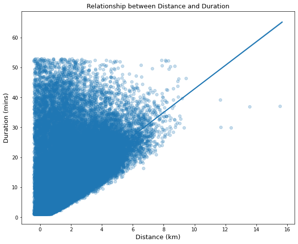

```python
print(f'The correlation between distance_km and duration_min is',
      bike_clean['duration_min'].corr(bike_clean['distance_km']).round(2))
plt.figure(figsize=(10,8))
sb.regplot(data = bike_clean, x = 'distance_km', y='duration_min', x_jitter=0.4, scatter_kws={'alpha':1/4})
plt.xlabel('Distance (km)', fontsize=13)
plt.ylabel('Duration (mins)', fontsize=13)
plt.title('Relationship between Distance and Duration', fontsize=13)
plt.show()
```

## Visualization 4: Which day of the week do subscribers and customers prefer to ride bikes?

- For subscribers, they prefer to ride bike on Thursday, so also are the customers too.
- The order for the most preferred week days for subscriber follows the order: Thur > Tue > Wed > Fri > Mon > Sat~Sun. They prefer to ride on Thursdays but not frequently on Saturdays or Sundays.
- for the customers, the order for the most preferred week days follows : Thur > Fri > Tue > Mon > Sun > Wed ~ Sat. They prefer to ride on Thursdays but not frequently on Wednesday and Saturdays.

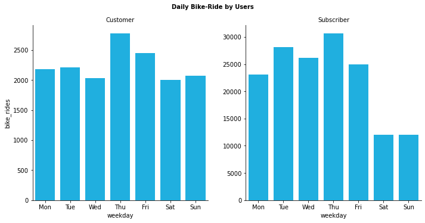

```python
week_order = ['Mon', 'Tue', 'Wed', 'Thu', 'Fri', 'Sat', 'Sun']
draw = sb.catplot(data=bike_clean, x='weekday', col="user_type", kind='count', sharey = False,
            color = 'deepskyblue', order = week_order)
draw.set_axis_labels("weekday", "bike_rides")
draw.set_titles("{col_name}")
draw.fig.suptitle('Daily Bike-Ride by Users', y=1.03, fontsize=10, fontweight='semibold');
```

## Visualization 5: Which day of the week do users spend the longest time riding bike?

- The days of the weekday both customers and subscribers spent the longest time riding is on Saturdays
- For customers, they spent the longest time on Saturdays and the shortest time on Wednesday riding bike
- For subscribers, they spent the longest time on Saturdays and the shortest time on Mondays and Tuedays riding bike

```python
# Write a function to avoid repetition of code
def multi_catnum(num, cat1, cat2, kind, height, col_wrap):

    if kind == "bar" and height== None and col_wrap ==None:
        plt.figure(figsize=(13,9))
        ax = sb.barplot(data = bike_clean, x = cat1, y = num, hue = cat2, palette='rocket_r')
        plt.setp(ax.axes, xlabel= cat1, ylabel= num);
        plt.title(f"Effect of Biker's {cat1} and {cat2} on {num}");


    elif kind == "barf" and height == height and col_wrap==col_wrap:
        g=sb.FacetGrid(data= bike_clean, col = cat1, margin_titles=True, col_wrap=col_wrap, height =height)
        g.map(sb.barplot, num, cat2, color='purple')
        g.fig.subplots_adjust(top=0.89);
        g.fig.suptitle(f"Effect of Biker's {cat1} and {cat2} on {num}");
        plt.show()
```

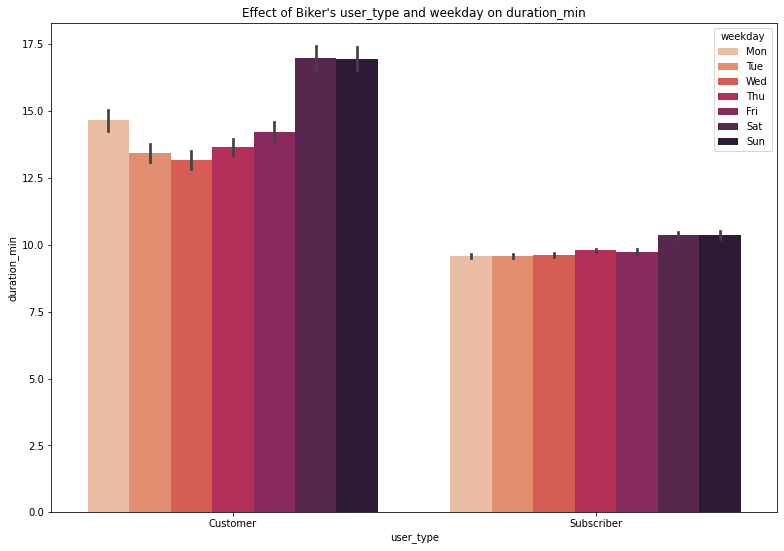

```python
multi_catnum('duration_min','user_type','weekday', kind='bar', height=None, col_wrap=None)
```

## Visualization 6: Relationship between User Type, Gender and Duration

> - For customers, the gender that spent the longest time biking are female.
> - For subscribers, the gender that spent the longest time biking are others besides male and female.
> - Amongst all user type, irrespective of whether they are customers or subscribers, the gender that spent the longest time biking are female customers and those that spent the shortest time biking are male subscribers

[figure not shown]

```python
plt.figure(figsize=(10,6))
sb.barplot(data =bike_clean, x = 'user_type', y= 'duration_min', hue = 'gender');
plt.xlabel('User Type', fontsize=13)
plt.ylabel('Number of Bikers', fontsize=13)
plt.title('Relationship between User Type, Gender and Duration', fontsize=13)
plt.show()
```

## Visualization 7: Relationship amongst Biker's User type, Distance and Duration

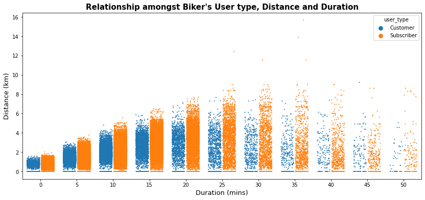

```python
plt.figure(figsize= [14, 6])
bike_clean['duration_min_int'] = ((bike_clean['duration_min']//5)*5).astype(int)
sb.stripplot(data = bike_clean, x='duration_min_int', y = 'distance_km', hue = 'user_type', size = 2, jitter = 0.35, dodge=True)
plt.xlabel('Duration (mins)', fontsize=13)
plt.ylabel('Distance (km)', fontsize=13)
plt.title("Relationship amongst Biker's User type, Distance and Duration",  fontsize = 15, fontweight = 'bold')
plt.show()
```

```python
!jupyter nbconvert Part_II_slide_deck_template.ipynb --to slides --post serve --no-input --no-prompt
```

[output not shown]